# TRABAJO_FINAL

Author

Cristina Martinez, Laura López, Veronica Yebra, Marina Parra

# 0. Carga de librerias y datos

```r
rm(list = ls())

set.seed(1234)

options(
  scipen = 999,
  dplyr.summarise.inform = FALSE
)
```

```r
library(tidyverse)
library(readxl)
library(janitor)
library(broom)
library(patchwork)
library(viridisLite)

library(skimr)
library(psych)
library(naniar)
library(mice)
library(VIM)
library(corrplot)
library(sf)
library(spdep)
library(spatialreg)
library(gstat)
library(automap)
library(terra)
library(stars)
library(tmap)
library(tidymodels)
library(parsnip)
library(recipes)
library(workflows)
library(yardstick)
library(rsample)

library(ranger)
library(lightgbm)
library(xgboost)
library(gbm)
library(kernlab)
library(kknn)
library(nnet)
```

```r
datos <- readRDS("./datos_depurados.rds")
head(datos)
```

```
Simple feature collection with 6 features and 24 fields
Geometry type: POINT
Dimension:     XY
Bounding box:  xmin: -3.754118 ymin: 40.37485 xmax: -3.647869 ymax: 40.48234
Geodetic CRS:  WGS 84
      X house.price   RP crime built.area  age  retired children immigrants
1 11548        3571 0.26  0.41         70 40.0 20.78242 12.64032  13.430590
2  7700        3115 0.14  0.28         61 40.0 16.94858 14.20422   7.080645
3  6271        2940 0.15  0.27         92 40.0 22.22094 13.08628   7.956299
4  1620        2811 0.20  0.35         65 40.0 12.39859 16.42624   6.552713
5  3500        3808 0.17  0.30        130 15.0 20.78242 12.64032  13.430590
6  1972        4407 0.22  0.53         75  7.5 21.81914 11.66186  13.947801
  shopping historical baths type.house        floor  good.cond garage elevator
1        0          0     2       piso      primera      bueno      0        0
2        0          0     1       piso   seg.-terc.      bueno      0        0
```

[output cut: 18 more lines]

Convertimos los datos a objeto espacial para poder trabajar con ellos

```r
datos_sf <- datos |>
  st_as_sf(
    coords = c("longitude", "latitude"),
    crs = 4326,
    remove = FALSE
  ) |>
  st_transform(25830)
```

```r
# Comprobaciones del objeto espacial
class(datos_sf)
```

```
[1] "sf"         "data.frame"
```

```r
st_crs(datos_sf)
```

[output not shown]

```r
head(st_coordinates(datos_sf))
```

```
            X       Y
[1,] 444312.1 4475836
[2,] 438854.5 4481544
[3,] 445029.2 4473352
[4,] 435981.8 4469636
[5,] 443149.4 4481398
[6,] 437915.7 4472945
```

```r
summary(st_coordinates(datos_sf)[, 1])
```

```
   Min. 1st Qu.  Median    Mean 3rd Qu.    Max.
 432797  439981  441349  441819  443610  451578
```

```r
summary(st_coordinates(datos_sf)[, 2])
```

```
   Min. 1st Qu.  Median    Mean 3rd Qu.    Max.
4465957 4471777 4474382 4474732 4477698 4484940
```

> Las coordenadas originales se han transformado a EPSG:25830, un sistema proyectado en metros. Esto permite definir vecindarios espaciales usando radios métricos, como 500 metros.

# 1. Dividimos en train y test

Dividimos el datatset en train y test para posteriormente evaluar la capacidad predictiva de los modelos.

```r
set.seed(1234)

datos_split <- initial_split(
  datos_sf,
  prop = 0.8,
  strata = log_precio_m2
)

datos_train <- training(datos_split)
datos_test  <- testing(datos_split)

nrow(datos_train)
```

```
[1] 7909
```

```r
nrow(datos_test)
```

```
[1] 1979
```

## Validación espacial

Vamos a utilizar una validacion aleatoria train-test, ya que nuestro objetivo es modelizar el precio de la vivienda dentro de zonas donde existen observaciones cercanas. Esto nos ayuda a predecir el precio de una vivienda nueva a partir de sus características y de su información espacial. Asi podemos comprobar el rendimiento de los modelos cuando las viviendas a predecir se encuentran dentro de la misma ventana espacial que las observaciones utilizadas en el entrenamiento. Es por ello que nos interesa que el conjunto de entrenamiento mantenga una distribución suficientemente densa dentro del área de validación, de forma que las predicciones puedan apoyarse en testigos cercanos.

Vamos a ver la distribución espacial de las observaciones de entrenamiento y test para comprobar que la partición aleatoria mantiene cobertura espacial en el ámbito de estudio.

```r
datos_train_osm <- datos_train |>
  st_transform(4326) |>
  mutate(muestra = "Train")

datos_test_osm <- datos_test |>
  st_transform(4326) |>
  mutate(muestra = "Test")

tmap_mode("plot")
```

```
ℹ tmap modes "plot" - "view"
ℹ toggle with `tmap::ttm()`
```

```r
mapa_train_test <-
  tm_shape(datos_train_osm) +
  tm_basemap("OpenStreetMap") +
  tm_dots(
    col = "#00BFC4",
    size = 0.25,
    alpha = 0.6) +
  tm_shape(datos_test_osm) +
  tm_dots(
    col = "#F8766D",
    size = 0.25,
    alpha = 0.85) +
  tm_add_legend(
    type = "symbol",
    labels = c("Train", "Test"),
    col = c("#00BFC4", "#F8766D"),
    title = "Muestra") +
  tm_title(
    "Distribución espacial de las muestras de entrenamiento y validación",
    fontface = "bold") +
  tm_layout(
    legend.outside = TRUE,
    legend.outside.position = "right",
    legend.outside.size = 0.12,
    legend.text.size = 0.5,
    legend.title.size = 0.7,
    inner.margins = c(0, 0, 0, 0),
    outer.margins = c(0, 0, 0, 0),
    asp = 0,
    frame = FALSE)
```

[output not shown]

```
[plot mode] fit legend/component: Some legend items or map compoments do not
fit well, and are therefore rescaled.
ℹ Set the tmap option `component.autoscale = FALSE` to disable rescaling.
```

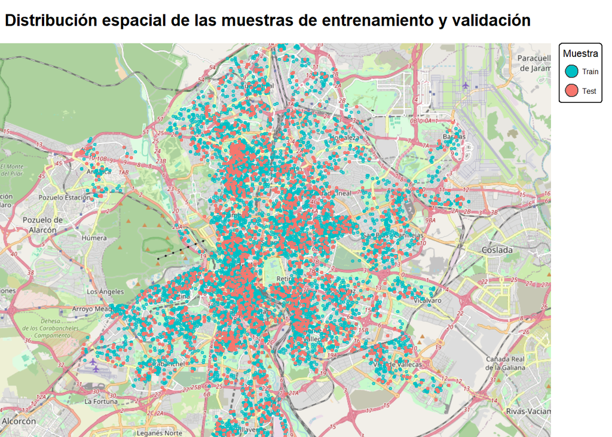

```r
mapa_train_test
```

> Con este mapa vemos que tanto las observaciones de entrenamiento como de test estan distribuidas de forma bastante similar en el espacio. Esto es lo que queriamos conseguir usando validacion espacial, de esta forma el conjunto test no queda aislado ni concentrado en una única zona, sino que se encuentra dentro del área cubierta por las observaciones de entrenamiento y podemos evaluar los modelos adecuadamente ya que tienen observaciones cercanas que pertenecen a train.

# 2. Matriz de pesos espaciales

Contruimos una matriz de pesos espaciales para el conjunto de entrenamiento.

Buscamos para cada vivienda qué otras viviendas están dentro de un radio de 500 metros. Utilizamos un radio de 500 metros porque representa un entorno urbano próximo. Las viviendas situadas a esta distancia pueden compartir características de localización, servicios, accesibilidad y entorno residencial.

```r
# Coordenadas del conjunto de entrenamiento
coords <- st_coordinates(datos_train)

# Vecinos dentro de 500 metros
list.dist500 <- dnearneigh(
  coords,
  d1 = 0,
  d2 = 500)

summary(list.dist500)
```

```
Neighbour list object:
Number of regions: 7909
Number of nonzero links: 504656
Percentage nonzero weights: 0.8067747
Average number of links: 63.80781
1 region with no links:
1832
Link number distribution:

  0   1   2   3   4   5   6   7   8   9  10  11  12  13  14  15  16  17  18  19
  1   5  13  20  21  28  42  42  45  52  75  71  59  65  67  74  70 100  96 111
 20  21  22  23  24  25  26  27  28  29  30  31  32  33  34  35  36  37  38  39
100  94 113 100  96  85  83 101 109  92  93  76 100  90  94  79  85  89 104  81
 40  41  42  43  44  45  46  47  48  49  50  51  52  53  54  55  56  57  58  59
 73  72  59  77  95  91  75  75  83  68  70  82  53  68  67  56  75  60  52  60
```

[output cut: 22 more lines]

La matriz de pesos se construye únicamente con las observaciones de entrenamiento para evitar que la información del conjunto de test intervenga en la fase de ajuste del modelo.

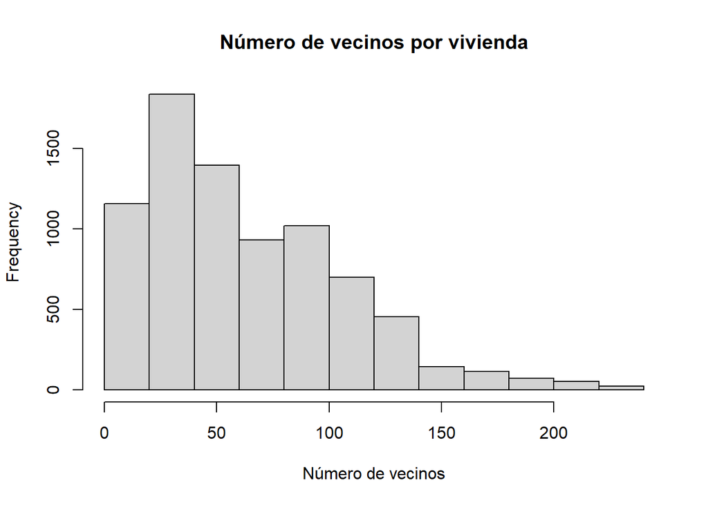

```r
# Número de vecinos
hist(
  card(list.dist500),
  main = "Número de vecinos por vivienda",
  xlab = "Número de vecinos"
)
```

> Con este histograma podemos ver si el radio elegido es demasiado restrictivo o demasiado amplio. Si muchas viviendas no tuvieran vecinos, el radio sería insuficiente para construir retardos espaciales estables. Sin embargo, observamos que la distribucion es heterogénea, lo que tiene sentido por la densidad residencial del area de estudio.

```r
# Comprobar si hay viviendas sin vecinos
table(card(list.dist500) == 0)
```

```
FALSE  TRUE
 7908     1
```

> Con un radio de 500 metros, prácticamente todas las viviendas del conjunto de entrenamiento tienen al menos un vecino: únicamente una observación queda aislada. Por tanto, el radio elegido permite construir una matriz de pesos espaciales suficientemente conectada sin recurrir a vecindarios excesivamente amplios.

Ahora si, hacemos la matriz transformando las distancias entre cada vivienda y sus vecinos en pesos inversos al cuadrado:

```r
# Distancias entre vecinos
distancias <- nbdists(
  list.dist500,
  coords)

# Comprobamos si hay distancias cero
sum(unlist(distancias) == 0)
```

```
[1] 0
```

```r
# Evitamos pesos infinitos en caso de viviendas con la misma coordenada
distancias <- lapply(distancias, function(x) {
  x[x == 0] <- 1
  x})

# Pesos inversos al cuadrado
pesos_inv2 <- lapply(distancias, function(x) {
  1 / (x^2)})

# Matriz de pesos espaciales
W_dist <- nb2listw(
  list.dist500,
  glist = pesos_inv2,
  style = "W",
  zero.policy = TRUE) # por la observacion aisalda
```

> Con la matriz espacial reunimos informacion espacial del entorno de cada vivienda y asi podemos utilizarla en los modelos con componente espacial.

Representamos el radio para verlo visualmente.

```r
# Muestra de viviendas para visualizar el radio de vecindad
set.seed(123)

idx_muestra_vecinos <- sample(seq_len(nrow(datos_train)), 25)

puntos_muestra <- datos_train[idx_muestra_vecinos, ]

# Círculos de 500 metros alrededor de las viviendas seleccionadas
buffers_muestra <- st_buffer(puntos_muestra, dist = 500)

# Pasamos a coordenadas geográficas para OSM
datos_train_osm <- datos_train |>
  st_transform(4326)

puntos_muestra_osm <- puntos_muestra |>
  st_transform(4326)

buffers_muestra_osm <- buffers_muestra |>
  st_transform(4326)
```

```r
tmap_mode("plot")
```

```
ℹ tmap modes "plot" - "view"
```

[figure not shown]

```r
tm_shape(datos_train_osm) +
  tm_tiles("OpenStreetMap") +
  tm_dots(
    fill = "grey40",
    size = 0.20,
    fill_alpha = 0.45,
    col = NA) +
  tm_shape(buffers_muestra_osm) +
  tm_borders(
    col = "red",
    lwd = 1.5) +
  tm_shape(puntos_muestra_osm) +
  tm_dots(
    fill = "black",
    size = 0.25,
    fill_alpha = 1,
    col = NA) +
  tm_title(
    "Radio de vecindad espacial de 500 metros",
    fontface = "bold") +
  tm_layout(
    legend.show = FALSE,
    frame = FALSE,
    inner.margins = c(0, 0, 0, 0),
    outer.margins = c(0, 0, 0, 0),
    asp = 0)
```

> Con este mapa observamos el radio de 500 metros (el circulo rojo) y vemos que, especialmente en las zonas más densas, las viviendas cuentan con suficientes observaciones cercanas para construir la matriz de pesos espaciales.

# 3. I de Morgan

> ¿El precio por m² presenta autocorrelación espacial en el conjunto de entrenamiento?

Como ya tenemos la matriz de pesos espaciales `W_dist`, vamos a comprobar si la variable que vamos a modelizar `log_precio_m2` presenta **autocorrelacion espacial** en el conjunto de entrenamiento.

Vamos a medir si el logaritmo del precio por metro cuadrado de cada vivienda está relacionado con el precio de las viviendas situadas en su entorno de 500 metros. El objetivo es comprobar si existe autocorrelación espacial en la variable dependiente, es decir, si las viviendas próximas tienden a presentar valores similares de precio.

La hipótesis nula del contraste de Moran es la ausencia de autocorrelación espacial. Por tanto, un valor positivo y significativo de la I de Moran indicaría que viviendas próximas tienden a presentar precios por metro cuadrado similares.

```r
# I de Moran global
moran_global <- moran.test(
  datos_train$log_precio_m2,
  listw = W_dist,
  zero.policy = TRUE,
  alternative = "greater",
  na.action = na.omit
)

moran_global
```

```
    Moran I test under randomisation

data:  datos_train$log_precio_m2
weights: W_dist
n reduced by no-neighbour observations

Moran I statistic standard deviate = 63.345, p-value <
0.00000000000000022
alternative hypothesis: greater
sample estimates:
Moran I statistic       Expectation          Variance
    0.52789965146    -0.00012647022     0.00006948501
```

> El contraste de Moran rechaza claramente la hipótesis nula de independencia espacial. El estadístico I de Moran es positivo y elevado (`I = 0.528`), con un p-valor prácticamente nulo, por lo que existe evidencia de autocorrelación espacial positiva en el logaritmo del precio por metro cuadrado.

> Esto significa que las viviendas próximas tienden a presentar precios por metro cuadrado similares: viviendas caras cerca de otras viviendas caras y viviendas más baratas cerca de viviendas más baratas. Por tanto, la variable objetivo presenta dependencia espacial inicial, lo que justifica analizar si los modelos predictivos son capaces de absorber esa estructura o si es necesario incorporar explícitamente información espacial.

Lo vemos graficamente y calculamos el retardo espacial.

```r
# Retardo espacial
datos_train$log_precio_m2_w <- lag.listw(
  W_dist,
  var = datos_train$log_precio_m2,
  zero.policy = TRUE)

# Comprobación del retardo espacial
sum(is.na(datos_train$log_precio_m2_w))
```

```
[1] 0
```

```r
summary(datos_train$log_precio_m2_w)
```

```
   Min. 1st Qu.  Median    Mean 3rd Qu.    Max.
  0.000   8.439   8.646   8.640   8.826  10.012
```

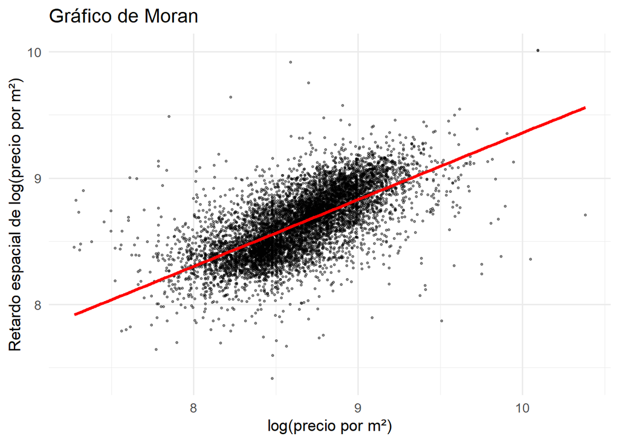

```r
datos_moran_plot <- datos_train |>
  filter(log_precio_m2_w != 0) # quitamos la vivienda aislada

ggplot(
  datos_moran_plot,
  aes(x = log_precio_m2, y = log_precio_m2_w)) +
  geom_point(
    color = "black",
    alpha = 0.35,
    size = 0.7) +
  geom_smooth(
    method = "lm",
    se = FALSE,
    color = "red",
    linewidth = 1.2) +
  labs(
    title = "Gráfico de Moran",
    x = "log(precio por m²)",
    y = "Retardo espacial de log(precio por m²)") +
  theme_minimal(base_size = 13)
```

> Observamos una clara relacion positiva entre el logaritmo del precio por metro cuadrado de cada vivienda y su retardo espacial, es decir, que las viviendas con precios caros estan cerca de otras viviendas caras, y las viviendas con precios mas bajos se rodean de otras viviendas con menor precio. Es por ello que vamos a incorporar en nuestros modelos las componentes espaciales para mejorar la capacidad predictiva y la dependencia espacial detectada.

## Ventana de prediccion

Definimos la ventana de prediccion.La idea es definir el área dentro de la cual tiene sentido hacer predicciones, es decir, la zona donde el modelo tiene suficientes datos de entrenamiento alrededor. Para predecir precios ‘como tasador’ necesitamos que las viviendas nuevas/test estén dentro de una zona con suficientes “testigos” o viviendas observadas alrededor. La ventana debe construirse con `datos_train`.

```r
# Ventana de predicción basada en el conjunto de entrenamiento
ventana_prediccion <- datos_train |>
  st_geometry() |>
  st_union() |>
  st_buffer(500) |>
  st_union()

# Comprobamos qué observaciones de test caen dentro de la ventana
test_dentro_ventana <- st_within(
  datos_test,
  ventana_prediccion,
  sparse = FALSE
)[, 1]

table(test_dentro_ventana)
```

```
test_dentro_ventana
TRUE
1979
```

Todas las viviendas de test están dentro de la ventana de predicción construida desde train.

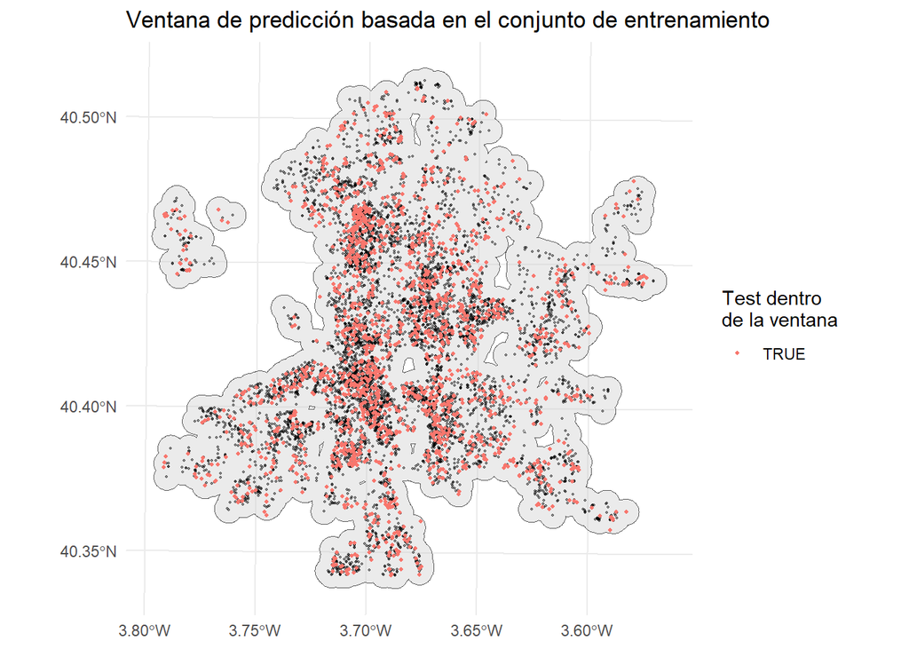

```r
datos_test$test_dentro_ventana <- test_dentro_ventana

ggplot() +
  geom_sf(data = st_as_sf(ventana_prediccion), fill = "grey80", alpha = 0.4) +
  geom_sf(data = datos_train, size = 0.4, alpha = 0.4) +
  geom_sf(data = datos_test, aes(color = test_dentro_ventana), size = 0.7) +
  labs(
    title = "Ventana de predicción basada en el conjunto de entrenamiento",
    color = "Test dentro\nde la ventana"
  ) +
  theme_minimal()
```

> Todas las observaciones del conjunto de test se encuentran dentro de la ventana de predicción construida a partir del conjunto de entrenamiento. Esto indica que el conjunto de entrenamiento proporciona cobertura espacial suficiente para evaluar modelos basados en proximidad espacial.

# 4. Modelos sin dependencia espacial explícita

Antes de estimar los modelos predictivos hacemos una base de datos sin geometría, ya que los algoritmos utilizados en esta sección trabajan con variables tabulares. Vamos a eliminar las coordenadas (`longitude` y `latitude`), la variable `cluster_dbscan` y el retardo espacial del precio, en caso de estar creado.

Queremos construir una primera familia de modelos que no utilicen información espacial explícita. Por lo que dejamos las características propias de la vivienda y algunas variables de entorno disponibles en la base de datos, como criminalidad, composición demográfica o proximidad a zonas comerciales/históricas, porque forman parte de la información observable asociada a cada vivienda.

Estos modelos servirán como referencia para comparar posteriormente si la incorporación explícita de información espacial mejora la capacidad predictiva.

```r
datos_train_mod <- datos_train |>
  st_drop_geometry() |>
  select(
    -any_of(c(
      "longitude",
      "latitude",
      "cluster_dbscan",
      "precio_m2", "house.price", "precio_actualizado", "log_precio_m2_w")))

datos_test_mod <- datos_test |>
  st_drop_geometry() |>
  select(
    -any_of(c(
      "longitude",
      "latitude",
      "cluster_dbscan",
      "precio_m2", "house.price", "precio_actualizado", "log_precio_m2_w")))
```

```r
rec_base <- recipe(
  log_precio_m2 ~ .,
  data = datos_train_mod
) |>
  step_unknown(all_nominal_predictors()) |>
  step_novel(all_nominal_predictors()) |>
  step_dummy(all_nominal_predictors()) |>
  step_zv(all_predictors()) |>
  step_normalize(all_numeric_predictors())
```

## 1. Modelo lineal (LM)

Entrenamos los datos en train

```r
lm_mod <- linear_reg() |>
  set_engine("lm")

# workflow
lm_wf <- workflow() |>
  add_recipe(rec_base) |>
  add_model(lm_mod)

# ajustar modelo
lm_fit <- fit(
  lm_wf,
  data = datos_train_mod)

# coeficientes
lm_fit |>
  extract_fit_parsnip() |>
  tidy()
```

```
# A tibble: 25 × 5
   term        estimate std.error statistic  p.value
   <chr>          <dbl>     <dbl>     <dbl>    <dbl>
 1 (Intercept)  8.64      0.00261   3315.   0
 2 X            0.00769   0.00267      2.88 4.03e- 3
 3 RP          -0.0151    0.00346     -4.36 1.33e- 5
 4 crime       -0.0395    0.00400     -9.87 7.76e-23
 5 built.area  -0.0310    0.00414     -7.50 7.31e-14
 6 age         -0.0318    0.00336     -9.47 3.67e-21
 7 retired      0.00503   0.00357      1.41 1.59e- 1
 8 children    -0.0497    0.00474    -10.5  1.25e-25
 9 immigrants  -0.0333    0.00393     -8.48 2.75e-17
10 baths        0.0259    0.00423      6.13 9.47e-10
# ℹ 15 more rows
```

Las predicciones son sobre el conjunto de datos test.

```r
pred_lm <- predict(
  lm_fit,
  new_data = datos_test_mod) |>
  bind_cols(datos_test_mod |> select(log_precio_m2)) |>
  mutate(
    modelo = "Lineal",
    residuo = log_precio_m2 - .pred)

# metricas
metricas_lm <- tibble(
  Modelo = "Lineal",
  RMSE = rmse(pred_lm, truth = log_precio_m2, estimate = .pred)$.estimate,
  MAE  = mae(pred_lm, truth = log_precio_m2, estimate = .pred)$.estimate,
  R2   = rsq(pred_lm, truth = log_precio_m2, estimate = .pred)$.estimate)
metricas_lm
```

```
# A tibble: 1 × 4
  Modelo  RMSE   MAE    R2
  <chr>  <dbl> <dbl> <dbl>
1 Lineal 0.238 0.183 0.486
```

> El modelo lineal obtiene un R² de 0.486, por lo que explica aproximadamente el 48,6% de la variabilidad del logaritmo del precio por metro cuadrado en el conjunto de test. Su RMSE es de 0.238 y su MAE de 0.183.

> Estos resultados indican que el modelo lineal tiene una capacidad predictiva moderada, pero limitada. Esto sugiere que la relación entre las características de la vivienda y el precio por metro cuadrado no es completamente lineal.

## 2. RandomForest

```r
# definir modelo
rf_mod <- rand_forest(
  trees = 500) |>
  set_engine("ranger") |>
  set_mode("regression")

# workflow
rf_wf <- workflow() |>
  add_recipe(rec_base) |>
  add_model(rf_mod)

# ajustar modelo
rf_fit <- fit(
  rf_wf,
  data = datos_train_mod)

# predicciones de test
pred_rf <- predict(
  rf_fit,
  datos_test_mod) |>
  bind_cols(
    datos_test_mod |>
      select(log_precio_m2)) |>
  mutate(
    modelo = "Random Forest",
    residuo = log_precio_m2 - .pred)

# metricas

metricas_rf <- tibble(
  Modelo = "Random Forest",
  RMSE = rmse(pred_rf, truth = log_precio_m2, estimate = .pred)$.estimate,
  MAE  = mae(pred_rf, truth = log_precio_m2, estimate = .pred)$.estimate,
  R2   = rsq(pred_rf, truth = log_precio_m2, estimate = .pred)$.estimate)

metricas_rf
```

```
# A tibble: 1 × 4
  Modelo         RMSE   MAE    R2
  <chr>         <dbl> <dbl> <dbl>
1 Random Forest 0.197 0.143 0.653
```

> El modelo Random Forest obtiene un R² de 0.653, por lo que explica aproximadamente el 65,3% de la variabilidad del logaritmo del precio por metro cuadrado en test. Su RMSE es de 0.197 y su MAE de 0.143.

> En comparación con el modelo lineal, el Random Forest mejora claramente la capacidad predictiva, ya que aumenta el R² y reduce tanto el RMSE como el MAE. Esto indica que un modelo no lineal basado en árboles capta mejor las relaciones entre las variables explicativas y el precio de la vivienda.

## 3. LightGBM

```r
rec_lgbm <- recipe(
  log_precio_m2 ~ .,
  data = datos_train_mod
) |>
  step_unknown(all_nominal_predictors()) |>
  step_novel(all_nominal_predictors()) |>
  step_dummy(all_nominal_predictors()) |>
  step_zv(all_predictors()) |>
  step_normalize(all_numeric_predictors())

# entrenar recipe
prep_lgbm <- prep(rec_lgbm)


# bake
train_baked <- bake(
  prep_lgbm,
  new_data = NULL)

test_baked <- bake(
  prep_lgbm,
  new_data = datos_test_mod)

# matrices
x_train <- train_baked |>
  select(-log_precio_m2) |>
  as.matrix()

y_train <- train_baked$log_precio_m2


x_test <- test_baked |>
  select(-log_precio_m2) |>
  as.matrix()

y_test <- test_baked$log_precio_m2

# datasets light
dtrain <- lgb.Dataset(
  data = x_train,
  label = y_train)

dtest <- lgb.Dataset(
  data = x_test,
  label = y_test)

modelo_lgbm <- lgb.train(
  params = list(
    objective = "regression",
    metric = "rmse",
    learning_rate = 0.05,
    num_leaves = 31,
    feature_fraction = 0.8),
 data = dtrain,
 nrounds = 500)
```

```
[LightGBM] [Info] Auto-choosing row-wise multi-threading, the overhead of testing was 0.002117 seconds.
You can set `force_row_wise=true` to remove the overhead.
And if memory is not enough, you can set `force_col_wise=true`.
[LightGBM] [Info] Total Bins 972
[LightGBM] [Info] Number of data points in the train set: 7909, number of used features: 24
[LightGBM] [Info] Start training from score 8.642268
```

```r
# predicciones sobre test
pred_lgbm <- predict(
  modelo_lgbm,
  x_test
)

pred_lgbm_df <- tibble(
  log_precio_m2 = y_test,
  .pred = pred_lgbm,
  modelo = "LightGBM",
  residuo = log_precio_m2 - .pred)

# metricas
metricas_lgbm <- tibble(
  Modelo = "LightGBM",
  RMSE = rmse(pred_lgbm_df, truth = log_precio_m2, estimate = .pred)$.estimate,
  MAE  = mae(pred_lgbm_df, truth = log_precio_m2, estimate = .pred)$.estimate,
  R2   = rsq(pred_lgbm_df, truth = log_precio_m2, estimate = .pred)$.estimate)

metricas_lgbm
```

```
# A tibble: 1 × 4
  Modelo    RMSE   MAE    R2
  <chr>    <dbl> <dbl> <dbl>
1 LightGBM 0.195 0.142 0.657
```

> El modelo LightGBM obtiene un R² de 0.657, por lo que explica aproximadamente el 65,7% de la variabilidad del logaritmo del precio por metro cuadrado en test. Su RMSE es de 0.195 y su MAE de 0.142.

> Este modelo presenta el mejor resultado dentro de esta primera familia de modelos, aunque la mejora respecto al Random Forest es pequeña. En concreto, obtiene un R² ligeramente superior y unos errores algo menores, por lo que puede considerarse el modelo con mejor rendimiento predictivo entre los modelos sin dependencia espacial explícita.

## 4. SVM

```r
svr_mod <- svm_rbf(
  cost = 1,
  rbf_sigma = 0.1
) |>
  set_engine("kernlab") |>
  set_mode("regression")

# workflow
svr_wf <- workflow() |>
  add_recipe(rec_base) |>
  add_model(svr_mod)

# ajustar modelo
svr_fit <- fit(
  svr_wf,
  data = datos_train_mod)

# predicciones test
pred_svr <- predict(
  svr_fit,
  datos_test_mod) |>

  bind_cols(
    datos_test_mod |>
      select(log_precio_m2)) |>
  mutate(
    modelo = "SVR",
    residuo = log_precio_m2 - .pred)

# metricas
metricas_svr <- tibble(
  Modelo = "SVM",
  RMSE = rmse(pred_svr, truth = log_precio_m2, estimate = .pred)$.estimate,
  MAE  = mae(pred_svr, truth = log_precio_m2, estimate = .pred)$.estimate,
  R2   = rsq(pred_svr, truth = log_precio_m2, estimate = .pred)$.estimate)
metricas_svr
```

```
# A tibble: 1 × 4
  Modelo  RMSE   MAE    R2
  <chr>  <dbl> <dbl> <dbl>
1 SVM    0.208 0.153 0.608
```

> El modelo SVM obtiene un R² de 0.608, por lo que explica aproximadamente el 60,8% de la variabilidad del logaritmo del precio por metro cuadrado en test. Su RMSE es de 0.208 y su MAE de 0.153.

> El SVM mejora claramente al modelo lineal, pero queda por debajo de los modelos basados en árboles, como Random Forest y LightGBM. Esto indica que captura cierta no linealidad en los datos, aunque en este caso no alcanza el rendimiento de los métodos ensemble.

## 5. KNN

```r
# definir modelo

knn_mod <- nearest_neighbor(
  neighbors = 5
) |>
  set_engine("kknn") |>
  set_mode("regression")

# workflow
knn_wf <- workflow() |>
  add_recipe(rec_base) |>
  add_model(knn_mod)

# ajustar modelo
knn_fit <- fit(
  knn_wf,
  data = datos_train_mod)

# predicciones sobre test
pred_knn <- predict(
  knn_fit,
  datos_test_mod) |>

  bind_cols(
    datos_test_mod |>
      select(log_precio_m2)) |>

  mutate(
    modelo = "KNN",
    residuo = log_precio_m2 - .pred)

# metricas
metricas_knn <- tibble(
  Modelo = "KNN",
  RMSE = rmse(pred_knn, truth = log_precio_m2, estimate = .pred)$.estimate,
  MAE  = mae(pred_knn, truth = log_precio_m2, estimate = .pred)$.estimate,
  R2   = rsq(pred_knn, truth = log_precio_m2, estimate = .pred)$.estimate)
metricas_knn
```

```
# A tibble: 1 × 4
  Modelo  RMSE   MAE    R2
  <chr>  <dbl> <dbl> <dbl>
1 KNN    0.232 0.170 0.523
```

> El modelo KNN obtiene un R² de 0.523, por lo que explica aproximadamente el 52,3% de la variabilidad del logaritmo del precio por metro cuadrado en test. Su RMSE es de 0.232 y su MAE de 0.170.

> El KNN mejora ligeramente al modelo lineal en términos de R² y RMSE, pero la mejora es reducida. Además, presenta errores superiores a los de Random Forest, LightGBM, SVM y Gradient Boosting, por lo que no parece ser una de las alternativas más competitivas en este caso.

## 6. GradientBoosting

```r
# =========================================================
# PREPROCESADO CON EL MISMO RECIPE QUE EL RESTO DE MODELOS
# =========================================================

prep_base <- prep(rec_base)

train_gbm <- bake(
  prep_base,
  new_data = NULL
)

test_gbm <- bake(
  prep_base,
  new_data = datos_test_mod
)


# =========================================================
# MODELO GRADIENT BOOSTING
# =========================================================

set.seed(123)

modelo_gbm <- gbm(
  formula = log_precio_m2 ~ .,
  data = train_gbm,
  distribution = "gaussian",
  n.trees = 500,
  interaction.depth = 4,
  shrinkage = 0.05,
  n.minobsinnode = 10,
  cv.folds = 5,
  verbose = FALSE)


# =========================================================
# MEJOR NÚMERO DE ÁRBOLES SEGÚN VALIDACIÓN CRUZADA
# =========================================================

best_iter <- gbm.perf(
  modelo_gbm,
  method = "cv",
  plot.it = FALSE)

best_iter
```

```
[1] 489
```

```r
# =========================================================
# PREDICCIONES SOBRE TEST
# =========================================================

pred_gbm <- predict(
  modelo_gbm,
  newdata = test_gbm,
  n.trees = best_iter)


# =========================================================
# DATAFRAME DE RESULTADOS
# =========================================================

pred_gbm_df <- tibble(
  log_precio_m2 = test_gbm$log_precio_m2,
  .pred = pred_gbm,
  modelo = "Gradient Boosting",
  residuo = log_precio_m2 - .pred)


# =========================================================
# MÉTRICAS
# =========================================================

metricas_gbm <- tibble(
  Modelo = "Gradient Boosting",
  RMSE = rmse(
    pred_gbm_df,
    truth = log_precio_m2,
    estimate = .pred
  )$.estimate,
  MAE = mae(
    pred_gbm_df,
    truth = log_precio_m2,
    estimate = .pred
  )$.estimate,
  R2 = rsq(
    pred_gbm_df,
    truth = log_precio_m2,
    estimate = .pred
  )$.estimate
)

metricas_gbm
```

```
# A tibble: 1 × 4
  Modelo             RMSE   MAE    R2
  <chr>             <dbl> <dbl> <dbl>
1 Gradient Boosting 0.204 0.151 0.625
```

> El modelo Gradient Boosting obtiene un R² de 0.625, por lo que explica aproximadamente el 62,5% de la variabilidad del logaritmo del precio por metro cuadrado en test. Su RMSE es de 0.204 y su MAE de 0.151.

> Este modelo mejora al modelo lineal, al KNN y al SVM en términos de R² y RMSE, aunque queda por debajo de Random Forest y LightGBM. Por tanto, dentro de los modelos sin dependencia espacial explícita, ofrece un rendimiento intermedio-alto, pero no es el mejor modelo de esta familia.

## Comparacion de modelos sin espacialidad

Comparamos todas las metricas de los modelos que no tienen espacialidad para ver cual es le mejor.

```r
metricas_no_espacial <- bind_rows(
  metricas_lm,
  metricas_rf,
  metricas_lgbm,
  metricas_svr,
  metricas_knn,
  metricas_gbm
) |>
  arrange(RMSE)

metricas_no_espacial
```

```
# A tibble: 6 × 4
  Modelo             RMSE   MAE    R2
  <chr>             <dbl> <dbl> <dbl>
1 LightGBM          0.195 0.142 0.657
2 Random Forest     0.197 0.143 0.653
3 Gradient Boosting 0.204 0.151 0.625
4 SVM               0.208 0.153 0.608
5 KNN               0.232 0.170 0.523
6 Lineal            0.238 0.183 0.486
```

> El mejor modelo sin componente espacial es **LightGBM**, porque es el que tiene un RMSE más bajo, MAE más bajo y R² más alto. Es decir, es el modelo que comete menos error medio en test y, además, el que explica mayor proporción de la variabilidad del `log_precio_m2`.

# 5. Residuos de los modelos

Una vez hemos estimado los modelos sin componente espacial nos calculamos la I de Moran sobre sus residuos con el objetivo de comprobar si los errores mantenían autocorrelación espacial

Este análisis se realiza sobre `train` porque la matriz de pesos `W_dist` se ha construido únicamente con las observaciones de entrenamiento. Por tanto, los resultados deben interpretarse como un diagnóstico de autocorrelación espacial residual del ajuste, no como una métrica predictiva out-of-sample.

```r
# =========================================================
# RESIDUOS EN TRAIN DE LOS MODELOS SIN DEPENDENCIA ESPACIAL EXPLÍCITA
# =========================================================

# LM
pred_lm_train <- predict(
  lm_fit,
  new_data = datos_train_mod)

datos_train$res_lm <- datos_train_mod$log_precio_m2 - pred_lm_train$.pred


# Random Forest
pred_rf_train <- predict(
  rf_fit,
  new_data = datos_train_mod)

datos_train$res_rf <- datos_train_mod$log_precio_m2 - pred_rf_train$.pred


# LightGBM
pred_lgbm_train <- predict(
  modelo_lgbm,
  x_train)

datos_train$res_lgbm <- y_train - pred_lgbm_train


# SVM
pred_svr_train <- predict(
  svr_fit,
  new_data = datos_train_mod)

datos_train$res_svr <- datos_train_mod$log_precio_m2 - pred_svr_train$.pred


# KNN
pred_knn_train <- predict(
  knn_fit,
  new_data = datos_train_mod)

datos_train$res_knn <- datos_train_mod$log_precio_m2 - pred_knn_train$.pred


# Gradient Boosting
pred_gbm_train <- predict(
  modelo_gbm,
  newdata = train_gbm,
  n.trees = best_iter)

datos_train$res_gbm <- train_gbm$log_precio_m2 - pred_gbm_train
```

```r
# =========================================================
# I DE MORAN SOBRE LOS RESIDUOS
# =========================================================

moran_lm <- moran.test(
  datos_train$res_lm,
  W_dist,
  zero.policy = TRUE,
  alternative = "greater")

moran_rf <- moran.test(
  datos_train$res_rf,
  W_dist,
  zero.policy = TRUE,
  alternative = "greater")

moran_lgbm <- moran.test(
  datos_train$res_lgbm,
  W_dist,
  zero.policy = TRUE,
  alternative = "greater")

moran_svr <- moran.test(
  datos_train$res_svr,
  W_dist,
  zero.policy = TRUE,
  alternative = "greater")

moran_knn <- moran.test(
  datos_train$res_knn,
  W_dist,
  zero.policy = TRUE,
  alternative = "greater")

moran_gbm <- moran.test(
  datos_train$res_gbm,
  W_dist,
  zero.policy = TRUE,
  alternative = "greater")
```

> Los contrastes de Moran sobre los residuos muestran si los errores de cada modelo siguen organizándose espacialmente. En todos los casos, un valor positivo y significativo indica que los residuos no se distribuyen aleatoriamente en el espacio, sino que tienden a agruparse territorialmente.

```r
# =========================================================
# TABLA RESUMEN DE MORAN SOBRE RESIDUOS
# =========================================================

moran_residuos <- tibble(
  Modelo = c(
    "Lineal",
    "Random Forest",
    "LightGBM",
    "SVM",
    "KNN",
    "Gradient Boosting"
  ),
  I_Moran = c(
    moran_lm$estimate[["Moran I statistic"]],
    moran_rf$estimate[["Moran I statistic"]],
    moran_lgbm$estimate[["Moran I statistic"]],
    moran_svr$estimate[["Moran I statistic"]],
    moran_knn$estimate[["Moran I statistic"]],
    moran_gbm$estimate[["Moran I statistic"]]
  ),
  p_value = c(
    moran_lm$p.value,
    moran_rf$p.value,
    moran_lgbm$p.value,
    moran_svr$p.value,
    moran_knn$p.value,
    moran_gbm$p.value
  )
) |>
  mutate(
    significativo = if_else(p_value < 0.05, "Sí", "No")
  ) |>
  arrange(desc(I_Moran))

moran_residuos
```

```
# A tibble: 6 × 4
  Modelo            I_Moran   p_value significativo
  <chr>               <dbl>     <dbl> <chr>
1 Lineal             0.205  2.33e-134 Sí
2 Gradient Boosting  0.112  2.78e- 41 Sí
3 SVM                0.0832 7.63e- 24 Sí
4 KNN                0.0597 3.46e- 13 Sí
5 Random Forest      0.0480 3.92e-  9 Sí
6 LightGBM           0.0393 1.10e-  6 Sí
```

> Los resultados muestran que los residuos de los modelos sin dependencia espacial explícita mantienen autocorrelación espacial positiva. Por tanto, aunque los modelos predictivos captan parte de la variabilidad del precio por metro cuadrado, todavía queda una estructura espacial residual que no está completamente explicada por las variables incluidas.

> El modelo lineal presenta la mayor autocorrelación espacial residual, lo que sugiere que su especificación es insuficiente para capturar la estructura territorial del precio. Los modelos más flexibles, especialmente los basados en árboles, reducen esta dependencia residual, pero no la eliminan por completo. LightGBM es el que tiene un menor valor en la I de Morgan.

# 6. Modelos con componente espacial

En este apartado se estiman versiones de los modelos anteriores incorporando explícitamente información espacial mediante el retardo espacial del precio. Este retardo representa, para cada vivienda, el precio medio ponderado de las viviendas cercanas.

La idea es comprobar si añadir esta información espacial mejora la capacidad predictiva y reduce la autocorrelación espacial residual detectada en los modelos anteriores.

Es importante distinguir entre el retardo espacial en `train` y en `test`. En `train`, el retardo se calcula usando la matriz de pesos entre viviendas de entrenamiento. En `test`, el retardo debe calcularse usando únicamente viviendas de `train` cercanas, ya que no se puede utilizar el precio observado de las viviendas de test para construir una variable predictora.

- **RETARDO ESPACIAL EN TRAIN**

```r
datos_train$log_precio_m2_w <- lag.listw(
  W_dist,
  var = datos_train$log_precio_m2,
  zero.policy = TRUE
)

summary(datos_train$log_precio_m2_w)
```

```
   Min. 1st Qu.  Median    Mean 3rd Qu.    Max.
  0.000   8.439   8.646   8.640   8.826  10.012
```

```r
sum(is.na(datos_train$log_precio_m2_w))
```

```
[1] 0
```

```r
sum(datos_train$log_precio_m2_w == 0)
```

```
[1] 1
```

El 0 viene de la vivienda de train sin vecinos y no es grave.

- **RETARDO ESPACIAL EN TEST** Ahora cada vivienda de test recibe un retardo espacial calculado con precios observados de viviendas de train cercanas.

```r
# retardo espacial en test usando los vecinos de train

calcular_lag_test_train <- function(datos_test, datos_train, variable, radio = 500, potencia = 2) {

  vecinos_test_train <- sf::st_is_within_distance(
    datos_test,
    datos_train,
    dist = radio
  )

  valores_train <- datos_train[[variable]]

  lag_test <- purrr::map2_dbl(
    vecinos_test_train,
    seq_along(vecinos_test_train),
    function(vecinos, i) {

      if (length(vecinos) == 0) {
        return(NA_real_)
      }

      distancias <- as.numeric(
        sf::st_distance(
          datos_test[i, ],
          datos_train[vecinos, ],
          by_element = FALSE
        )
      )

      distancias[distancias == 0] <- 1

      pesos <- 1 / (distancias ^ potencia)

      sum(valores_train[vecinos] * pesos, na.rm = TRUE) /
        sum(pesos, na.rm = TRUE)
    }
  )

  return(lag_test)
}


datos_test$log_precio_m2_w <- calcular_lag_test_train(
  datos_test = datos_test,
  datos_train = datos_train,
  variable = "log_precio_m2",
  radio = 500,
  potencia = 2
)

summary(datos_test$log_precio_m2_w)
```

```
   Min. 1st Qu.  Median    Mean 3rd Qu.    Max.
  7.591   8.429   8.647   8.638   8.815   9.573
```

```r
sum(is.na(datos_test$log_precio_m2_w))
```

```
[1] 0
```

- **Datasets espacializados limpios**

Aqui si dejamos `log_precio_m2_w`. Esa es la diferencia respecto a los modelos sin dependencia espacial explícita.

```r
datos_train_sp <- datos_train |>
  st_drop_geometry() |>
  select(
    -any_of(c(
      "X",
      "longitude",
      "latitude",
      "cluster_dbscan",
      "precio_m2",
      "house.price",
      "precio_actualizado",
      "res_lm",
      "res_rf",
      "res_lgbm",
      "res_svr",
      "res_knn",
      "res_gbm",
      "res_sar",
      "res_rf_sp",
      "res_lgbm_sp",
      "res_svr_sp",
      "res_knn_sp",
      "res_gbm_sp"
    ))
  )

datos_test_sp <- datos_test |>
  st_drop_geometry() |>
  select(
    -any_of(c(
      "X",
      "longitude",
      "latitude",
      "cluster_dbscan",
      "precio_m2",
      "house.price",
      "precio_actualizado",
      "res_lm",
      "res_rf",
      "res_lgbm",
      "res_svr",
      "res_knn",
      "res_gbm",
      "res_sar",
      "res_rf_sp",
      "res_lgbm_sp",
      "res_svr_sp",
      "res_knn_sp",
      "res_gbm_sp"
    ))
  )

names(datos_train_sp)
```

```
 [1] "RP"              "crime"           "built.area"      "age"
 [5] "retired"         "children"        "immigrants"      "shopping"
 [9] "historical"      "baths"           "type.house"      "floor"
[13] "good.cond"       "garage"          "elevator"        "air.cond"
[17] "swimming.pool"   "M.30"            "log_precio_m2"   "log_precio_m2_w"
```

```r
names(datos_test_sp)
```

```
 [1] "RP"                  "crime"               "built.area"
 [4] "age"                 "retired"             "children"
 [7] "immigrants"          "shopping"            "historical"
[10] "baths"               "type.house"          "floor"
[13] "good.cond"           "garage"              "elevator"
[16] "air.cond"            "swimming.pool"       "M.30"
[19] "log_precio_m2"       "test_dentro_ventana" "log_precio_m2_w"
```

Para mantener el orden nos creamos un recipe espacial

```r
rec_sp <- recipe(
  log_precio_m2 ~ .,
  data = datos_train_sp
) |>
  step_unknown(all_nominal_predictors()) |>
  step_novel(all_nominal_predictors()) |>
  step_dummy(all_nominal_predictors()) |>
  step_zv(all_predictors()) |>
  step_normalize(all_numeric_predictors())
```

## 1. Modelo lineal

```r
# =========================================================
# MODELO LINEAL ESPACIAL
# =========================================================

lm_sp_mod <- linear_reg() |>
  set_engine("lm")

lm_sp_wf <- workflow() |>
  add_recipe(rec_sp) |>
  add_model(lm_sp_mod)

lm_sp_fit <- fit(
  lm_sp_wf,
  data = datos_train_sp
)

pred_lm_sp <- predict(
  lm_sp_fit,
  new_data = datos_test_sp
) |>
  bind_cols(datos_test_sp |> select(log_precio_m2)) |>
  mutate(
    modelo = "Lineal espacial",
    residuo = log_precio_m2 - .pred
  )

metricas_lm_sp <- tibble(
  Modelo = "Lineal espacial",
  RMSE = rmse(pred_lm_sp, truth = log_precio_m2, estimate = .pred)$.estimate,
  MAE  = mae(pred_lm_sp, truth = log_precio_m2, estimate = .pred)$.estimate,
  R2   = rsq(pred_lm_sp, truth = log_precio_m2, estimate = .pred)$.estimate
)

metricas_lm_sp
```

```
# A tibble: 1 × 4
  Modelo           RMSE   MAE    R2
  <chr>           <dbl> <dbl> <dbl>
1 Lineal espacial 0.225 0.170 0.540
```

*¿Ahora los residuos guardan dependencia espacial?*

```r
# =========================================================
# MORAN RESIDUOS MODELO LINEAL ESPACIAL
# =========================================================

pred_lm_sp_train <- predict(
  lm_sp_fit,
  new_data = datos_train_sp
)

datos_train$res_lm_sp <- datos_train_sp$log_precio_m2 - pred_lm_sp_train$.pred

moran_lm_sp <- moran.test(
  datos_train$res_lm_sp,
  W_dist,
  zero.policy = TRUE,
  alternative = "greater"
)

moran_lm_sp
```

```
    Moran I test under randomisation

data:  datos_train$res_lm_sp
weights: W_dist
n reduced by no-neighbour observations

Moran I statistic standard deviate = -2.4289, p-value = 0.9924
alternative hypothesis: greater
sample estimates:
Moran I statistic       Expectation          Variance
   -0.02036599301    -0.00012647022     0.00006943803
```

Es decir, los residuos pasan a comportarse de forma espacialmente aleatoria y, por tanto, la incorporación de la componente espacial permite capturar la dependencia espacial presente en los datos.

## 2. RandomForest

```r
rf_sp_mod <- rand_forest(
  trees = 500
) |>
  set_engine("ranger") |>
  set_mode("regression")

rf_sp_wf <- workflow() |>
  add_recipe(rec_sp) |>
  add_model(rf_sp_mod)

rf_sp_fit <- fit(
  rf_sp_wf,
  data = datos_train_sp)

pred_rf_sp <- predict(
  rf_sp_fit,
  new_data = datos_test_sp) |>
  bind_cols(datos_test_sp |> select(log_precio_m2)) |>
  mutate(
    modelo = "Random Forest espacial",
    residuo = log_precio_m2 - .pred)

metricas_rf_sp <- tibble(
  Modelo = "Random Forest espacial",
  RMSE = rmse(pred_rf_sp, truth = log_precio_m2, estimate = .pred)$.estimate,
  MAE  = mae(pred_rf_sp, truth = log_precio_m2, estimate = .pred)$.estimate,
  R2   = rsq(pred_rf_sp, truth = log_precio_m2, estimate = .pred)$.estimate)

metricas_rf_sp
```

```
# A tibble: 1 × 4
  Modelo                  RMSE   MAE    R2
  <chr>                  <dbl> <dbl> <dbl>
1 Random Forest espacial 0.196 0.142 0.655
```

¿Ahora los residuos guardan dependencia espacial?

```r
pred_rf_sp_train <- predict(
  rf_sp_fit,
  new_data = datos_train_sp)

datos_train$res_rf_sp <- datos_train_sp$log_precio_m2 - pred_rf_sp_train$.pred

moran_rf_sp <- moran.test(
  datos_train$res_rf_sp,
  W_dist,
  zero.policy = TRUE,
  alternative = "greater")

moran_rf_sp
```

```
    Moran I test under randomisation

data:  datos_train$res_rf_sp
weights: W_dist
n reduced by no-neighbour observations

Moran I statistic standard deviate = -6.6493, p-value = 1
alternative hypothesis: greater
sample estimates:
Moran I statistic       Expectation          Variance
   -0.05553623923    -0.00012647022     0.00006944135
```

En los residuos del `RandomForest` tambien obtenemos independencia espacial ya que el estadístico no es estadísticamente significativo, es decir, que el modelo espacial conseguido reducir la dependencia espacial que permanecía en los errores de los modelos sin componente espacial.

## 3. LightGBM

```r
rec_lgbm_sp <- recipe(
  log_precio_m2 ~ .,
  data = datos_train_sp
) |>
  step_unknown(all_nominal_predictors()) |>
  step_novel(all_nominal_predictors()) |>
  step_dummy(all_nominal_predictors()) |>
  step_zv(all_predictors()) |>
  step_normalize(all_numeric_predictors())

prep_lgbm_sp <- prep(rec_lgbm_sp)

train_baked_sp <- bake(
  prep_lgbm_sp,
  new_data = NULL)

test_baked_sp <- bake(
  prep_lgbm_sp,
  new_data = datos_test_sp)

x_train_sp <- train_baked_sp |>
  select(-log_precio_m2) |>
  as.matrix()

y_train_sp <- train_baked_sp$log_precio_m2

x_test_sp <- test_baked_sp |>
  select(-log_precio_m2) |>
  as.matrix()

y_test_sp <- test_baked_sp$log_precio_m2

dtrain_sp <- lgb.Dataset(
  data = x_train_sp,
  label = y_train_sp)

set.seed(123)

modelo_lgbm_sp <- lgb.train(
  params = list(
    objective = "regression",
    metric = "rmse",
    learning_rate = 0.05,
    num_leaves = 31,
    feature_fraction = 0.8
  ),
  data = dtrain_sp,
  nrounds = 500)
```

```
[LightGBM] [Info] Auto-choosing row-wise multi-threading, the overhead of testing was 0.026861 seconds.
You can set `force_row_wise=true` to remove the overhead.
And if memory is not enough, you can set `force_col_wise=true`.
[LightGBM] [Info] Total Bins 972
[LightGBM] [Info] Number of data points in the train set: 7909, number of used features: 24
[LightGBM] [Info] Start training from score 8.642268
```

```r
pred_lgbm_sp <- predict(
  modelo_lgbm_sp,
  x_test_sp)

pred_lgbm_sp_df <- tibble(
  log_precio_m2 = y_test_sp,
  .pred = pred_lgbm_sp,
  modelo = "LightGBM espacial",
  residuo = log_precio_m2 - .pred)

metricas_lgbm_sp <- tibble(
  Modelo = "LightGBM espacial",
  RMSE = rmse(pred_lgbm_sp_df, truth = log_precio_m2, estimate = .pred)$.estimate,
  MAE  = mae(pred_lgbm_sp_df, truth = log_precio_m2, estimate = .pred)$.estimate,
  R2   = rsq(pred_lgbm_sp_df, truth = log_precio_m2, estimate = .pred)$.estimate)

metricas_lgbm_sp
```

```
# A tibble: 1 × 4
  Modelo             RMSE   MAE    R2
  <chr>             <dbl> <dbl> <dbl>
1 LightGBM espacial 0.194 0.141 0.658
```

```r
#### MORAN LIGHTGBM ESPACIAL
pred_lgbm_sp_train <- predict(
  modelo_lgbm_sp,
  x_train_sp)

datos_train$res_lgbm_sp <- y_train_sp - pred_lgbm_sp_train

moran_lgbm_sp <- moran.test(
  datos_train$res_lgbm_sp,
  W_dist,
  zero.policy = TRUE,
  alternative = "greater")

moran_lgbm_sp
```

```
    Moran I test under randomisation

data:  datos_train$res_lgbm_sp
weights: W_dist
n reduced by no-neighbour observations

Moran I statistic standard deviate = -5.3398, p-value = 1
alternative hypothesis: greater
sample estimates:
Moran I statistic       Expectation          Variance
   -0.04462690994    -0.00012647022     0.00006945144
```

El contraste de Moran sobre los residuos no es significativo, por lo que no hay evidencia de autocorrelación espacial residual. Esto indica que la incorporación del retardo espacial permite capturar la estructura espacial que quedaba sin explicar en los modelos anteriores.

## 4. SVM

```r
#### SVM ESPACIALIZADO

svr_sp_mod <- svm_rbf(
  cost = 1,
  rbf_sigma = 0.1
) |>
  set_engine("kernlab") |>
  set_mode("regression")

svr_sp_wf <- workflow() |>
  add_recipe(rec_sp) |>
  add_model(svr_sp_mod)

svr_sp_fit <- fit(
  svr_sp_wf,
  data = datos_train_sp
)

pred_svr_sp <- predict(
  svr_sp_fit,
  new_data = datos_test_sp
) |>
  bind_cols(datos_test_sp |> select(log_precio_m2)) |>
  mutate(
    modelo = "SVM espacial",
    residuo = log_precio_m2 - .pred
  )

metricas_svr_sp <- tibble(
  Modelo = "SVM espacial",
  RMSE = rmse(pred_svr_sp, truth = log_precio_m2, estimate = .pred)$.estimate,
  MAE  = mae(pred_svr_sp, truth = log_precio_m2, estimate = .pred)$.estimate,
  R2   = rsq(pred_svr_sp, truth = log_precio_m2, estimate = .pred)$.estimate
)

metricas_svr_sp
```

```
# A tibble: 1 × 4
  Modelo        RMSE   MAE    R2
  <chr>        <dbl> <dbl> <dbl>
1 SVM espacial 0.205 0.148 0.619
```

```r
#### MORAN SVM ESPACIAL

# =========================================================
# MORAN RESIDUOS SVM ESPACIAL
# =========================================================

pred_svr_sp_train <- predict(
  svr_sp_fit,
  new_data = datos_train_sp
)

datos_train$res_svr_sp <- datos_train_sp$log_precio_m2 - pred_svr_sp_train$.pred

moran_svr_sp <- moran.test(
  datos_train$res_svr_sp,
  W_dist,
  zero.policy = TRUE,
  alternative = "greater"
)

moran_svr_sp
```

```
    Moran I test under randomisation

data:  datos_train$res_svr_sp
weights: W_dist
n reduced by no-neighbour observations

Moran I statistic standard deviate = -2.174, p-value = 0.9851
alternative hypothesis: greater
sample estimates:
Moran I statistic       Expectation          Variance
   -0.01823705505    -0.00012647022     0.00006939597
```

SVR tambien nos sale no significativo.

## 5. KNN

```r
# =========================================================
# KNN ESPACIAL
# =========================================================

knn_sp_mod <- nearest_neighbor(
  neighbors = 5
) |>
  set_engine("kknn") |>
  set_mode("regression")

knn_sp_wf <- workflow() |>
  add_recipe(rec_sp) |>
  add_model(knn_sp_mod)

knn_sp_fit <- fit(
  knn_sp_wf,
  data = datos_train_sp
)

pred_knn_sp <- predict(
  knn_sp_fit,
  new_data = datos_test_sp
) |>
  bind_cols(datos_test_sp |> select(log_precio_m2)) |>
  mutate(
    modelo = "KNN espacial",
    residuo = log_precio_m2 - .pred
  )

metricas_knn_sp <- tibble(
  Modelo = "KNN espacial",
  RMSE = rmse(pred_knn_sp, truth = log_precio_m2, estimate = .pred)$.estimate,
  MAE  = mae(pred_knn_sp, truth = log_precio_m2, estimate = .pred)$.estimate,
  R2   = rsq(pred_knn_sp, truth = log_precio_m2, estimate = .pred)$.estimate
)

metricas_knn_sp
```

```
# A tibble: 1 × 4
  Modelo        RMSE   MAE    R2
  <chr>        <dbl> <dbl> <dbl>
1 KNN espacial 0.225 0.165 0.547
```

```r
# =========================================================
# MORAN RESIDUOS KNN ESPACIAL
# =========================================================

pred_knn_sp_train <- predict(
  knn_sp_fit,
  new_data = datos_train_sp
)

datos_train$res_knn_sp <- datos_train_sp$log_precio_m2 - pred_knn_sp_train$.pred

moran_knn_sp <- moran.test(
  datos_train$res_knn_sp,
  W_dist,
  zero.policy = TRUE,
  alternative = "greater"
)

moran_knn_sp
```

```
    Moran I test under randomisation

data:  datos_train$res_knn_sp
weights: W_dist
n reduced by no-neighbour observations

Moran I statistic standard deviate = -0.33523, p-value = 0.6313
alternative hypothesis: greater
sample estimates:
Moran I statistic       Expectation          Variance
   -0.00292002607    -0.00012647022     0.00006944288
```

I de Moran no significativa, independencia espacial en los residuos.

## 6. GradientBoosting

```r
# =========================================================
# GRADIENT BOOSTING ESPACIAL
# =========================================================

prep_sp <- prep(rec_sp)

train_gbm_sp <- bake(
  prep_sp,
  new_data = NULL
)

test_gbm_sp <- bake(
  prep_sp,
  new_data = datos_test_sp
)

set.seed(123)

modelo_gbm_sp <- gbm(
  formula = log_precio_m2 ~ .,
  data = train_gbm_sp,
  distribution = "gaussian",
  n.trees = 500,
  interaction.depth = 4,
  shrinkage = 0.05,
  n.minobsinnode = 10,
  cv.folds = 5,
  verbose = FALSE
)

best_iter_sp <- gbm.perf(
  modelo_gbm_sp,
  method = "cv",
  plot.it = FALSE
)

best_iter_sp
```

```
[1] 500
```

```r
pred_gbm_sp <- predict(
  modelo_gbm_sp,
  newdata = test_gbm_sp,
  n.trees = best_iter_sp
)

pred_gbm_sp_df <- tibble(
  log_precio_m2 = test_gbm_sp$log_precio_m2,
  .pred = pred_gbm_sp,
  modelo = "Gradient Boosting espacial",
  residuo = log_precio_m2 - .pred
)

metricas_gbm_sp <- tibble(
  Modelo = "Gradient Boosting espacial",
  RMSE = rmse(pred_gbm_sp_df, truth = log_precio_m2, estimate = .pred)$.estimate,
  MAE  = mae(pred_gbm_sp_df, truth = log_precio_m2, estimate = .pred)$.estimate,
  R2   = rsq(pred_gbm_sp_df, truth = log_precio_m2, estimate = .pred)$.estimate
)

metricas_gbm_sp
```

```
# A tibble: 1 × 4
  Modelo                      RMSE   MAE    R2
  <chr>                      <dbl> <dbl> <dbl>
1 Gradient Boosting espacial 0.202 0.148 0.632
```

```r
# =========================================================
# MORAN RESIDUOS GRADIENT BOOSTING ESPACIAL
# =========================================================

pred_gbm_sp_train <- predict(
  modelo_gbm_sp,
  newdata = train_gbm_sp,
  n.trees = best_iter_sp
)

datos_train$res_gbm_sp <- train_gbm_sp$log_precio_m2 - pred_gbm_sp_train

moran_gbm_sp <- moran.test(
  datos_train$res_gbm_sp,
  W_dist,
  zero.policy = TRUE,
  alternative = "greater"
)

moran_gbm_sp
```

```
    Moran I test under randomisation

data:  datos_train$res_gbm_sp
weights: W_dist
n reduced by no-neighbour observations

Moran I statistic standard deviate = -8.382, p-value = 1
alternative hypothesis: greater
sample estimates:
Moran I statistic       Expectation          Variance
   -0.06997917302    -0.00012647022     0.00006944967
```

Independencia espacial en los residuos.

## Comparacion de los modelos espacializados

Depues de estimar los modelos con componente espacial y calcular la I de Morgan sobre sus residuos, obtenemos que todos los contrastes no son estadísticamente significativos, lo que significa que no se observa autocorrelacion espacial residual, es decir, que los modelos han capturado la componente espacial de mis datos. Para saber que modelo es mejor, miramos las metricas.

```r
metricas_espacial <- bind_rows(
  metricas_lm_sp,
  metricas_rf_sp,
  metricas_lgbm_sp,
  metricas_svr_sp,
  metricas_knn_sp,
  metricas_gbm_sp
) |>
  arrange(RMSE)

metricas_espacial
```

```
# A tibble: 6 × 4
  Modelo                      RMSE   MAE    R2
  <chr>                      <dbl> <dbl> <dbl>
1 LightGBM espacial          0.194 0.141 0.658
2 Random Forest espacial     0.196 0.142 0.655
3 Gradient Boosting espacial 0.202 0.148 0.632
4 SVM espacial               0.205 0.148 0.619
5 Lineal espacial            0.225 0.170 0.540
6 KNN espacial               0.225 0.165 0.547
```

Dentro de los modelos con dependencia espacial explícita, **LightGBM** espacial obtiene el mejor rendimiento predictivo, ya que presenta el menor RMSE, el menor MAE y el mayor R² en el conjunto de test. No obstante, la diferencia respecto al Random Forest espacial es reducida, por lo que ambos modelos muestran un comportamiento muy similar. En conjunto, los modelos basados en árboles siguen siendo los que mejor captan la relación entre las características de la vivienda, la información del entorno y el retardo espacial del precio.

# 7. Kriging

El kriging permite modelizar explícitamente la dependencia espacial mediante el semivariograma y realizar predicciones espaciales continuas sobre el territorio. Con kriging podemos predecir el valor de una variable en puntos donde no la observamos, usando la información de puntos cercanos y la estructura espacial de los datos.

La diferencia con los modelos anteriores es que usan las características de la vivienda para predecir, mientras que el kriging usa la localización y la dependecia espacial entre observaciones. Asique, lo usamos para predecir el logaritmo del precio por metro cuadrado, aprovechando la dependencia espacial detectada entre viviendas cercanas. De forma que las predicciones se basan no solo en la proximidad espacial, sino también en la estructura de dependencia estimada a partir de los datos.

## Kriging ordinario

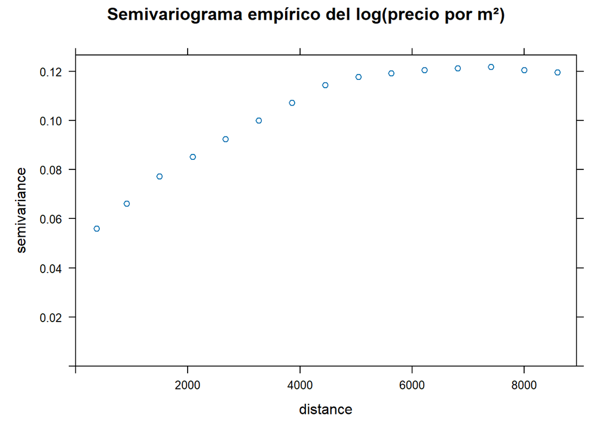

```r
# =========================================================
# TRAIN PARA KRIGING ORDINARIO
# =========================================================

kriging_train <- datos_train |>
  select(log_precio_m2)

# =========================================================
# SEMIVARIOGRAMA EMPÍRICO
# =========================================================

variograma_emp <- variogram(
  log_precio_m2 ~ 1,
  data = kriging_train
)

plot(
  variograma_emp,
  main = "Semivariograma empírico del log(precio por m²)"
)
```

> El semivariograma empírico muestra que la semivarianza aumenta con la distancia, lo que indica que las viviendas más próximas presentan valores más similares del precio por metro cuadrado. A medida que la distancia crece, las diferencias entre viviendas aumentan hasta alcanzar una zona de estabilización. Este comportamiento confirma la existencia de dependencia espacial y justifica el uso de métodos geoestadísticos como Kriging para realizar predicciones espaciales.

## Ajuste automático del semivariograma

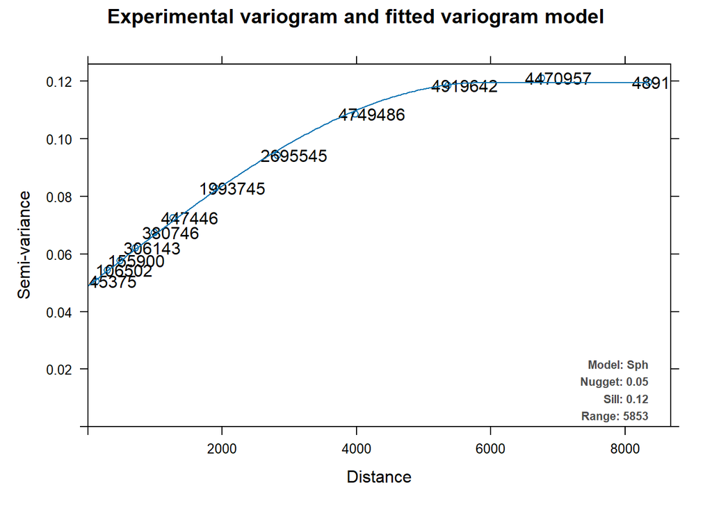

```r
# =========================================================
# AJUSTE AUTOMÁTICO DEL SEMIVARIOGRAMA
# =========================================================

modelo_variograma <- autofitVariogram(
  log_precio_m2 ~ 1,
  kriging_train
)

plot(
  modelo_variograma
)
```

```r
modelo_variograma$var_model
```

```
  model      psill    range
1   Nug 0.04891671    0.000
2   Sph 0.07056358 5852.736
```

## Kriging sobre test

```r
kriging_pred <- krige(
  formula = log_precio_m2 ~ 1,
  locations = kriging_train,
  newdata = datos_test,
  model = modelo_variograma$var_model
)
```

```
[using ordinary kriging]
```

```r
kriging_pred
```

```
Simple feature collection with 1979 features and 2 fields
Geometry type: POINT
Dimension:     XY
Bounding box:  xmin: 432797.2 ymin: 4465963 xmax: 451309.3 ymax: 4484658
Projected CRS: ETRS89 / UTM zone 30N
First 10 features:
   var1.pred   var1.var                 geometry
1   8.772895 0.05225681 POINT (440191.4 4472922)
2   8.467029 0.05519300 POINT (447232.6 4472214)
3   8.360579 0.05276640 POINT (443525.3 4471174)
4   8.855063 0.05164345   POINT (440071 4473840)
5   8.615734 0.05144822 POINT (440116.3 4478069)
6   8.672548 0.05209767 POINT (439441.4 4480795)
7   8.614119 0.05125420 POINT (440693.6 4479277)
8   8.840081 0.05224252   POINT (443465 4477666)
9   8.719147 0.05165899 POINT (443002.5 4477144)
10  8.652367 0.05845774 POINT (448719.8 4474705)
```

## Predicciones y metricas

```r
# predicciones
pred_kriging_df <- tibble(
  log_precio_m2 = datos_test$log_precio_m2,
  .pred = kriging_pred$var1.pred,
  modelo = "Kriging ordinario",
  residuo = log_precio_m2 - .pred
)

head(pred_kriging_df)
```

```
# A tibble: 6 × 4
  log_precio_m2 .pred modelo            residuo
          <dbl> <dbl> <chr>               <dbl>
1          8.98  8.77 Kriging ordinario  0.205
2          8.39  8.47 Kriging ordinario -0.0754
3          8.48  8.36 Kriging ordinario  0.118
4          8.97  8.86 Kriging ordinario  0.115
5          8.57  8.62 Kriging ordinario -0.0497
6          8.81  8.67 Kriging ordinario  0.135
```

```r
# metricas
metricas_kriging <- tibble(
  Modelo = "Kriging ordinario",
  RMSE = rmse(pred_kriging_df, truth = log_precio_m2, estimate = .pred)$.estimate,
  MAE  = mae(pred_kriging_df, truth = log_precio_m2, estimate = .pred)$.estimate,
  R2   = rsq(pred_kriging_df, truth = log_precio_m2, estimate = .pred)$.estimate
)

metricas_kriging
```

```
# A tibble: 1 × 4
  Modelo             RMSE   MAE    R2
  <chr>             <dbl> <dbl> <dbl>
1 Kriging ordinario 0.237 0.176 0.491
```

Esta tabla muestra la comparación entre el valor real y el valor predicho por Kriging para algunas viviendas del conjunto de test.

Comparándolo con los modelos anteriores, Kriging queda muy parecido al modelo lineal, pero bastante por debajo de los mejores modelos predictivos. Esto puede deberse a que el precio de la vivienda depende no solo de la localización, sino también de características internas del inmueble que Kriging no incorpora directamente en esta especificación.

Ahora obtenemos los residuos

```r
datos_test$res_kriging <- pred_kriging_df$residuo

summary(datos_test$res_kriging)
```

```
     Min.   1st Qu.    Median      Mean   3rd Qu.      Max.
-1.203366 -0.120407  0.012002  0.005886  0.146639  1.176501
```

## Matriz espacial en test

```r
coords_test <- st_coordinates(datos_test)

nb_test_moran <- dnearneigh(
  coords_test,
  d1 = 0,
  d2 = 500
)
summary(nb_test_moran)
```

```
Neighbour list object:
Number of regions: 1979
Number of nonzero links: 30326
Percentage nonzero weights: 0.7743255
Average number of links: 15.3239
19 regions with no links:
114, 201, 305, 499, 633, 750, 824, 993, 1038, 1144, 1233, 1416, 1590,
1629, 1663, 1788, 1853, 1889, 1976
47 disjoint connected subgraphs
Link number distribution:

  0   1   2   3   4   5   6   7   8   9  10  11  12  13  14  15  16  17  18  19
 19  33  64  54  72 101 100  86 122 104  84  85  91  73  57  63  51  41  52  44
 20  21  22  23  24  25  26  27  28  29  30  31  32  33  34  35  36  37  38  39
 49  36  37  22  37  32  38  35  23  31  20  15  25  22  20  17  14  14  14  13
 40  41  42  43  44  45  46  47  48  49  50  51  52  53  55  57  59
 17  12   4   2   2   2   2   5   7   3   1   5   1   1   3   1   1
33 least connected regions:
24 54 62 98 173 242 288 357 400 416 435 543 574 610 757 758 845 933 964 1374 1414 1473 1522 1549 1576 1651 1690 1695 1731 1823 1856 1891 1914 with 1 link
1 most connected region:
1871 with 59 links
```

```r
table(card(nb_test_moran) == 0)
```

```
FALSE  TRUE
 1960    19
```

```r
dist_test <- nbdists(
  nb_test_moran,
  coords_test
)

# Control de distancias cero
sum(unlist(dist_test) == 0)
```

```
[1] 0
```

```r
dist_test <- lapply(
  dist_test,
  function(d) {
    d[d == 0] <- 1
    d
  }
)

pesos_test <- lapply(
  dist_test,
  function(d) 1 / (d^2)
)

W_test_moran <- nb2listw(
  nb_test_moran,
  glist = pesos_test,
  style = "W",
  zero.policy = TRUE
)
```

Hacemos la I de Moran para los residuos del kriging

```r
moran_kriging <- moran.test(
  datos_test$res_kriging,
  W_test_moran,
  zero.policy = TRUE,
  alternative = "greater"
)

moran_kriging
```

```
    Moran I test under randomisation

data:  datos_test$res_kriging
weights: W_test_moran
n reduced by no-neighbour observations

Moran I statistic standard deviate = 3.0399, p-value = 0.001183
alternative hypothesis: greater
sample estimates:
Moran I statistic       Expectation          Variance
     0.0551856715     -0.0005104645      0.0003356907
```

#### MAPA DE PREDICCIONES KRIGING

```r
# =========================================================
# MAPA DE PREDICCIONES KRIGING
# =========================================================

kriging_mapa <- datos_test |>
  mutate(
    pred_kriging = kriging_pred$var1.pred
  ) |>
  st_transform(4326)

tmap_mode("plot")
```

```
ℹ tmap modes "plot" - "view"
```

[output not shown]

[figure not shown]

```r
tm_shape(kriging_mapa) +
  tm_basemap("OpenStreetMap") +
  tm_dots(
    col = "pred_kriging",
    palette = "viridis",
    size = 0.12,
    alpha = 0.8
  ) +
  tm_title(
    "Predicciones mediante Kriging ordinario",
    fontface = "bold"
  ) +
  tm_layout(
    frame = FALSE,
    legend.outside = TRUE
  )
```

Con este mapa observamos dónde predice Kriging precios por m² más altos y más bajos en el conjunto de test. Observamos que las predicciones nos son homogéneas en el espacio, sino que presentan diferencias según la localización, lo que indica que el método capta parte de la estructura espacial del precio. No obstante, al basarse principalmente en la localización, su capacidad predictiva es inferior a la de los modelos que incorporan las características de las viviendas.

# 8. Comparativa final de los modelos

Comparamos las metricas de todos los modelos que hemos hecho, con espacialidad, sin espacialidad y el kriging ordinario.

```r
# =========================================================
# COMPARACIÓN FINAL DE TODOS LOS MODELOS
# =========================================================

metricas_final <- bind_rows(
  metricas_lm,
  metricas_rf,
  metricas_lgbm,
  metricas_svr,
  metricas_knn,
  metricas_gbm,
  metricas_lm_sp,
  metricas_rf_sp,
  metricas_lgbm_sp,
  metricas_svr_sp,
  metricas_knn_sp,
  metricas_gbm_sp,
  metricas_kriging
) |>
  mutate(
    Tipo = case_when(
      Modelo %in% c(
        "Lineal",
        "Random Forest",
        "LightGBM",
        "SVM",
        "KNN",
        "Gradient Boosting"
      ) ~ "Sin dependencia espacial explícita",

      Modelo %in% c(
        "Lineal espacial",
        "Random Forest espacial",
        "LightGBM espacial",
        "SVM espacial",
        "KNN espacial",
        "Gradient Boosting espacial"
      ) ~ "Con dependencia espacial explícita",

      Modelo == "Kriging ordinario" ~ "Kriging ordinario",

      TRUE ~ "Otro"
    )
  ) |>
  arrange(RMSE)

metricas_final
```

```
# A tibble: 13 × 5
   Modelo                      RMSE   MAE    R2 Tipo
   <chr>                      <dbl> <dbl> <dbl> <chr>
 1 LightGBM espacial          0.194 0.141 0.658 Con dependencia espacial explíc…
 2 LightGBM                   0.195 0.142 0.657 Sin dependencia espacial explíc…
 3 Random Forest espacial     0.196 0.142 0.655 Con dependencia espacial explíc…
 4 Random Forest              0.197 0.143 0.653 Sin dependencia espacial explíc…
 5 Gradient Boosting espacial 0.202 0.148 0.632 Con dependencia espacial explíc…
 6 Gradient Boosting          0.204 0.151 0.625 Sin dependencia espacial explíc…
 7 SVM espacial               0.205 0.148 0.619 Con dependencia espacial explíc…
 8 SVM                        0.208 0.153 0.608 Sin dependencia espacial explíc…
 9 Lineal espacial            0.225 0.170 0.540 Con dependencia espacial explíc…
10 KNN espacial               0.225 0.165 0.547 Con dependencia espacial explíc…
11 KNN                        0.232 0.170 0.523 Sin dependencia espacial explíc…
12 Kriging ordinario          0.237 0.176 0.491 Kriging ordinario
13 Lineal                     0.238 0.183 0.486 Sin dependencia espacial explíc…
```

Por último, el Kriging presenta un rendimiento similar al modelo lineal, pero inferior al de los modelos de machine learning. Esto indica que, aunque la localización aporta información relevante, el precio por metro cuadrado depende también de características internas de la vivienda que los modelos predictivos capturan mejor.

Comparamos graficamente el RMSE:

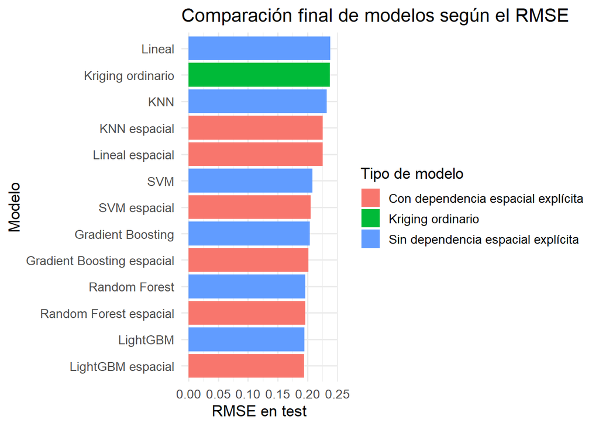

```r
# grafico comparativo
ggplot(
  metricas_final,
  aes(x = reorder(Modelo, RMSE), y = RMSE, fill = Tipo)
) +
  geom_col() +
  coord_flip() +
  labs(
    title = "Comparación final de modelos según el RMSE",
    x = "Modelo",
    y = "RMSE en test",
    fill = "Tipo de modelo"
  ) +
  theme_minimal(base_size = 13)
```

Comparamos graficamente el R2:

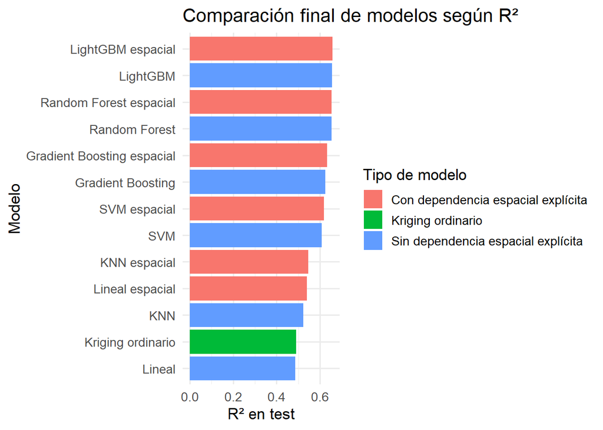

```r
ggplot(
  metricas_final,
  aes(x = reorder(Modelo, R2), y = R2, fill = Tipo)
) +
  geom_col() +
  coord_flip() +
  labs(
    title = "Comparación final de modelos según R²",
    x = "Modelo",
    y = "R² en test",
    fill = "Tipo de modelo"
  ) +
  theme_minimal(base_size = 13)
```

# 9. Ensamblado

Ahora vamos a hacer el modelo final que usaremos para predecir usando el ensamblado. Con el ensamblado combinamos varios modelos con el objetivo de obtener una prediccion final mas robusta y estable. De esta forma aprovechamos la información de los modelos y reducimos la dependencia de los errores particulares de cada uno.

```r
# =========================================================
# ENSAMBLADO PONDERADO
# =========================================================

# =========================================================
# PREDICCIONES INDIVIDUALES
# =========================================================

pred_rf_ens <- pred_rf_sp$.pred

pred_lgbm_ens <- pred_lgbm_sp_df$.pred

pred_gbm_ens <- pred_gbm_sp_df$.pred

pred_svr_ens <- pred_svr_sp$.pred

pred_knn_ens <- pred_knn_sp$.pred


pred_ensemble_weighted <- (
  pred_lgbm_ens * 0.35 +
  pred_rf_ens   * 0.35 +
  pred_gbm_ens  * 0.15 +
  pred_svr_ens  * 0.10 +
  pred_knn_ens  * 0.05
)

pred_ensemble_weighted_df <- tibble(
  log_precio_m2 = datos_test_sp$log_precio_m2,
  .pred = pred_ensemble_weighted,
  modelo = "Ensamblado espacial ponderado",
  residuo = log_precio_m2 - .pred
)

metricas_ensemble_weighted <- tibble(
  Modelo = "Ensamblado espacial ponderado",

  RMSE = rmse(
    pred_ensemble_weighted_df,
    truth = log_precio_m2,
    estimate = .pred
  )$.estimate,

  MAE = mae(
    pred_ensemble_weighted_df,
    truth = log_precio_m2,
    estimate = .pred
  )$.estimate,

  R2 = rsq(
    pred_ensemble_weighted_df,
    truth = log_precio_m2,
    estimate = .pred
  )$.estimate
)

metricas_ensemble_weighted
```

```
# A tibble: 1 × 4
  Modelo                         RMSE   MAE    R2
  <chr>                         <dbl> <dbl> <dbl>
1 Ensamblado espacial ponderado 0.193 0.140 0.665
```

Para realizar la predicción hemos hecho un ensamblado ponderado, dandole más pesos a los modelos que tenían mejor calidad predictiva. Para ello, no hemos incluido en el ensamblado el Krigging ya que tenía una peor calidad predictiva y lo más probabale es que añadiera ruido a la predicción.

# 10. Shinny

## 1. Guardamos los objetos

```r
saveRDS(rf_sp_fit, "rf_sp_fit.rds")
saveRDS(modelo_lgbm_sp, "modelo_lgbm_sp.rds")
saveRDS(modelo_gbm_sp, "modelo_gbm_sp.rds")
saveRDS(svr_sp_fit, "svr_sp_fit.rds")
saveRDS(knn_sp_fit, "knn_sp_fit.rds")

saveRDS(prep_sp, "prep_sp.rds")

saveRDS(ventana_prediccion, "ventana_prediccion.rds")

saveRDS(datos_train, "datos_train.rds")
```

## barrios

```r
barrios <- st_read("Barrios/BARRIOS.shp")
barrios <- st_transform(barrios, 4326)

names(barrios)
```

```
 [1] "CODDIS"     "NOMDIS"     "COD_BAR"    "NOMBRE"     "COD_DIS_TX"
 [6] "BARRIO_MAY" "COD_DISBAR" "NUM_BAR"    "BARRIO_MT"  "COD_DISB"
[11] "Area"       "geometry"
```

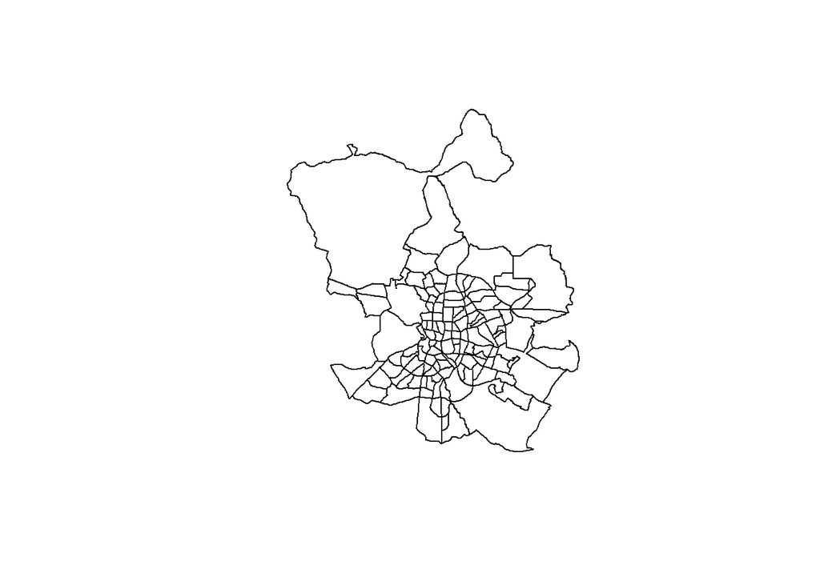

```r
plot(st_geometry(barrios))
```

## 2. App

```r
# =============================================================================
# TASADOR INTELIGENTE DE VIVIENDAS - SHINY APP
# Predicción del precio por m² mediante ensamblado de modelos ML
# =============================================================================

library(shiny)
library(bs4Dash)
library(tidyverse)
library(sf)
library(leaflet)
library(leaflet.extras)
library(spdep)
library(tidymodels)
library(lightgbm)
library(gbm)
library(kernlab)
library(kknn)
library(ranger)
library(waiter)
library(shinyWidgets)
library(plotly)
library(fresh)
# =============================================================================
# CARGA DE MODELOS Y OBJETOS
# =============================================================================

rf_sp_fit        <- readRDS("rf_sp_fit.rds")
modelo_lgbm_sp   <- readRDS("modelo_lgbm_sp.rds")
modelo_gbm_sp    <- readRDS("modelo_gbm_sp.rds")
svr_sp_fit       <- readRDS("svr_sp_fit.rds")
knn_sp_fit       <- readRDS("knn_sp_fit.rds")
prep_sp          <- readRDS("prep_sp.rds")
ventana_prediccion <- readRDS("ventana_prediccion.rds")
datos_train      <- readRDS("datos_train.rds")
barrios          <- st_read("Barrios/BARRIOS.shp") |> st_transform(4326)
# =============================================================================
# FUNCIÓN: RETARDO ESPACIAL PARA UNA NUEVA OBSERVACIÓN
# =============================================================================

calcular_lag_nuevo <- function(nuevo_punto_sf, datos_train, radio = 500, potencia = 2) {
  datos_train_proj <- st_transform(datos_train, 25830)
  nuevo_proj       <- st_transform(nuevo_punto_sf, 25830)

  vecinos <- st_is_within_distance(nuevo_proj, datos_train_proj, dist = radio)[[1]]

  if (length(vecinos) == 0) return(NA_real_)

  distancias <- as.numeric(st_distance(nuevo_proj, datos_train_proj[vecinos, ], by_element = FALSE))
  distancias[distancias == 0] <- 1
  pesos <- 1 / (distancias ^ potencia)

  sum(datos_train$log_precio_m2[vecinos] * pesos, na.rm = TRUE) /
    sum(pesos, na.rm = TRUE)
}

# =============================================================================
# FUNCIÓN PRINCIPAL DE PREDICCIÓN (ENSAMBLADO PONDERADO)
# =============================================================================

predecir_precio <- function(nueva_obs_df) {

  nueva_baked <- bake(prep_sp, new_data = nueva_obs_df)

  # LightGBM
  x_nuevo <- nueva_baked |> select(-log_precio_m2) |> as.matrix()
  pred_lgbm <- predict(modelo_lgbm_sp, x_nuevo)

  # Random Forest
  pred_rf   <- predict(rf_sp_fit, new_data = nueva_obs_df)$.pred

  # GBM
  nueva_baked_gbm <- bake(prep_sp, new_data = nueva_obs_df)
  pred_gbm  <- predict(modelo_gbm_sp, newdata = nueva_baked_gbm,
                       n.trees = modelo_gbm_sp$n.trees)

  # SVR
  pred_svr  <- predict(svr_sp_fit, new_data = nueva_obs_df)$.pred

  # KNN
  pred_knn  <- predict(knn_sp_fit, new_data = nueva_obs_df)$.pred

  # Ensamblado ponderado (mismos pesos del script original)
  pred_log <- pred_lgbm * 0.35 +
              pred_rf   * 0.35 +
              pred_gbm  * 0.15 +
              pred_svr  * 0.10 +
              pred_knn  * 0.05

  # Volver a escala original (exponencial)
  precio_m2 <- exp(pred_log)
  return(list(
    precio_m2   = precio_m2,
    pred_log    = pred_log,
    pred_lgbm   = exp(pred_lgbm),
    pred_rf     = exp(pred_rf),
    pred_gbm    = exp(pred_gbm),
    pred_svr    = exp(pred_svr),
    pred_knn    = exp(pred_knn)
  ))
}

# =============================================================================
# PALETA Y TEMA
# =============================================================================

mi_tema <- create_theme(
  bs4dash_vars(
    navbar_light_color        = "#fff",
    navbar_light_active_color = "#fff"
  ),
  bs4dash_sidebar_light(
    bg     = "#1a1a2e",
    color  = "#eee",
    hover_color = "#fff",
    active_color = "#e94560"
  ),
  bs4dash_color(
    blue = "#16213e",
    red  = "#e94560"
  )
)

# =============================================================================
# UI
# =============================================================================

ui <- bs4DashPage(
  freshTheme = mi_tema,
  title = "Tasador Inteligente",
  preloader = list(html = tagList(spin_flower(), h4("Cargando modelos...")), color = "#1a1a2e"),

  header = bs4DashNavbar(
    title = bs4DashBrand(
      title = tags$span(
        tags$i(class = "fas fa-home", style = "color:#e94560; margin-right:8px;"),
        tags$strong("TasadorIA", style = "color:white; font-size:1.3rem;"),
        tags$small(" | Predicción del precio de vivienda", style = "color:#aaa; font-size:0.8rem;")
      ),
      color = "white"
    )
  ),

  sidebar = bs4DashSidebar(
    skin = "dark",
    bs4SidebarMenu(
      bs4SidebarMenuItem("Tasador",         tabName = "tasador",   icon = icon("calculator")),
      bs4SidebarMenuItem("Mapa de barrios", tabName = "mapa",      icon = icon("map-marked-alt")),
      bs4SidebarMenuItem("Modelos",         tabName = "modelos",   icon = icon("chart-bar")),
      bs4SidebarMenuItem("Información",     tabName = "info",      icon = icon("info-circle"))
    )
  ),

  body = bs4DashBody(
    # CSS personalizado
    tags$head(
      tags$style(HTML("
        body { background-color: #f0f2f5 !important; font-family: 'Segoe UI', sans-serif; }

        .card { border-radius: 12px !important; box-shadow: 0 4px 20px rgba(0,0,0,0.08) !important; border: none !important; }
        .card-header { border-radius: 12px 12px 0 0 !important; font-weight: 600; }

        .precio-box {
          background: linear-gradient(135deg, #e94560, #0f3460);
          border-radius: 16px;
          padding: 30px;
          text-align: center;
          color: white;
          box-shadow: 0 8px 30px rgba(233,69,96,0.35);
          transition: transform 0.2s;
        }
        .precio-box:hover { transform: translateY(-3px); }
        .precio-valor { font-size: 3.2rem; font-weight: 800; letter-spacing: -1px; }
        .precio-label { font-size: 1rem; opacity: 0.85; margin-top: 5px; }
        .precio-total { font-size: 1.5rem; font-weight: 600; margin-top: 10px; opacity: 0.9; }
```

```r
        .warning-box {
          background: linear-gradient(135deg, #ff6b35, #f7c59f);
          border-radius: 12px; padding: 20px; color: white;
          box-shadow: 0 4px 15px rgba(255,107,53,0.3);
        }
        .warning-box h4 { font-weight: 700; margin-bottom: 8px; }

        .seccion-header {
          font-size: 0.75rem; font-weight: 700; letter-spacing: 1.5px;
          color: #e94560; text-transform: uppercase; margin: 18px 0 10px;
          border-bottom: 2px solid #e94560; padding-bottom: 4px;
        }

        .selector-card { cursor: pointer; transition: all 0.2s; border-radius: 10px !important;
                         border: 2px solid #dee2e6 !important; }
        .selector-card:hover { border-color: #e94560 !important; transform: translateY(-2px); }
        .selector-card.selected { border-color: #e94560 !important; background: #fff5f7 !important; }

        .barrio-label { font-size: 0.75rem; font-weight: 600; color: #555; text-align: center; padding: 8px; }

        .metric-mini { background: #fff; border-radius: 10px; padding: 12px 16px;
                       margin-bottom: 8px; border-left: 4px solid #e94560; }
        .metric-mini .valor { font-size: 1.4rem; font-weight: 700; color: #1a1a2e; }
        .metric-mini .etiqueta { font-size: 0.75rem; color: #888; margin-top: 2px; }

        .btn-tasar {
          background: linear-gradient(135deg, #e94560, #c0392b) !important;
          border: none !important; border-radius: 50px !important;
          font-size: 1.1rem !important; font-weight: 700 !important;
          padding: 14px 40px !important; letter-spacing: 0.5px !important;
          box-shadow: 0 6px 20px rgba(233,69,96,0.4) !important;
          transition: all 0.2s !important; color: white !important;
        }
        .btn-tasar:hover { transform: translateY(-2px) !important; box-shadow: 0 10px 25px rgba(233,69,96,0.5) !important; }

        .form-control { border-radius: 8px !important; border: 1.5px solid #dee2e6 !important; }
        .form-control:focus { border-color: #e94560 !important; box-shadow: 0 0 0 3px rgba(233,69,96,0.15) !important; }

        .leaflet-container { border-radius: 12px; }

        .badge-modelo { display: inline-block; background: #1a1a2e; color: white;
                        border-radius: 20px; padding: 3px 10px; font-size: 0.7rem; margin: 2px; }

        .coords-badge { background: #1a1a2e; color: #e94560; border-radius: 8px;
                        padding: 8px 14px; font-family: monospace; font-size: 0.85rem; display: inline-block; }

        .info-card-header { background: linear-gradient(135deg, #1a1a2e, #0f3460) !important; color: white !important; }

        .prog-bar-custom .progress-bar { background: linear-gradient(90deg, #e94560, #c0392b); }
      "))
    ),

    bs4TabItems(

      # -----------------------------------------------------------------------
      # TAB 1: TASADOR
      # -----------------------------------------------------------------------
      bs4TabItem(tabName = "tasador",
        fluidRow(
          # --- Panel izquierdo: formulario ---
          column(width = 5,
            bs4Card(
              width = 12, solidHeader = TRUE, status = "danger",
              headerBorder = FALSE,
              header = tagList(
                tags$i(class = "fas fa-sliders-h", style = "margin-right:8px;"),
                "Características de la vivienda"
              ),

              # UBICACIÓN
              tags$div(class = "seccion-header", tags$i(class = "fas fa-map-pin", style = "margin-right:6px;"), "Ubicación"),
              fluidRow(
                column(6,
                  numericInput("lat_input", label = tags$span(tags$i(class="fas fa-globe", style="color:#e94560;"), " Latitud"),
                               value = 40.416, step = 0.001, min = 40.3, max = 40.55)
                ),
                column(6,
                  numericInput("lon_input", label = tags$span(tags$i(class="fas fa-globe", style="color:#e94560;"), " Longitud"),
                               value = -3.703, step = 0.001, min = -3.85, max = -3.55)
                )
              ),
              tags$p(tags$small(class = "text-muted",
                tags$i(class = "fas fa-info-circle"), " Selecciona el barrio en el ",
                tags$strong("mapa"), " para rellenar las coordenadas automáticamente.")),

              tags$hr(style="margin: 12px 0;"),

              # CARACTERÍSTICAS FÍSICAS
              tags$div(class = "seccion-header", tags$i(class = "fas fa-ruler-combined", style = "margin-right:6px;"), "Características físicas"),
              fluidRow(
                column(6,
                  numericInput("built_area", label = tags$span(tags$i(class="fas fa-expand-arrows-alt", style="color:#e94560;"), " Metros cuadrados"),
                               value = 80, min = 20, max = 500, step = 5)
                ),
                column(6,
                  numericInput("baths", label = tags$span(tags$i(class="fas fa-bath", style="color:#e94560;"), " Baños"),
                               value = 1, min = 1, max = 6, step = 1)
                )
              ),
              fluidRow(
                column(6,
                  numericInput("age", label = tags$span(tags$i(class="fas fa-calendar-alt", style="color:#e94560;"), " Antigüedad (años)"),
                               value = 20, min = 0, max = 120, step = 1)
                ),
                column(6,
                  numericInput("floor", label = tags$span(tags$i(class="fas fa-building", style="color:#e94560;"), " Planta"),
                               value = 3, min = 0, max = 30, step = 1)
                )
              ),

              tags$hr(style="margin: 12px 0;"),

              # TIPO Y EXTRAS
              tags$div(class = "seccion-header", tags$i(class = "fas fa-star", style = "margin-right:6px;"), "Tipo y extras"),

              fluidRow(
                column(6,
                  selectInput("type_house", label = tags$span(tags$i(class="fas fa-home", style="color:#e94560;"), " Tipo de vivienda"),
                              choices = c("Piso" = "piso", "Casa" = "casa", "Ático" = "atico",
                                          "Dúplex" = "duplex", "Estudio" = "estudio"),
                              selected = "piso")
                ),
                column(6,
                  selectInput("good_cond", label = tags$span(tags$i(class="fas fa-check-circle", style="color:#e94560;"), " Buen estado"),
                              choices = c("Sí" = 1, "No" = 0), selected = 1)
                )
              ),
```